# Implementing a Neural Network

# Neural network for longitudinal data

The aim of this notebook is to predict 5 years mortality for patients diagnosed with hypertension before the age of 65 using on their disease history. To accomplish this task, we will use the synthetic data provided.

Here we load the libraries used for the data transformation, for the neural network implementation and for the analysis of the results. If a library is missing, you can install it using the command *install.packages(pkgs)*.

```r
library(tidyverse)
library(lubridate)
library(pROC)
library(keras3)
```

Here you can load the three files used in this notebook. I would suggest spending some time here to understand the content of the different files. Use head to visualize the three tables. In order to make transformation to the dates, we need to parse them as such. Either load the tables parsing directly the columns as date or use the command *as.Date* to convert them in the desired format - check which columns should be dates. Note that lpr.tsv only contains hypertension disease codes.

```r
cpr <- read.csv('cpr.tsv', sep='\t', header = TRUE)
lpr <- read.csv('lpr.tsv', sep='\t', header = TRUE)
trj <- read.csv('trj.tsv', sep='\t', header = TRUE)

head (cpr)
```

|  | ID | SEX | BIRTHDAY | STATUS | STATUS_DATE |
| --- | --- | --- | --- | --- | --- |
| 1 | 1 | M | 1971-07-26 | 1 | 2017-03-01 |
| 2 | 2 | M | 1922-10-30 | 90 | 2002-07-15 |
| 3 | 3 | M | 1960-05-14 | 1 | 2017-03-01 |
| 4 | 4 | K | 1945-04-10 | 1 | 2017-03-01 |
| 5 | 6 | M | 1932-06-08 | 1 | 2017-03-01 |
| 6 | 7 | M | 1949-12-10 | 1 | 2017-03-01 |

```r
head (lpr)
```

|  | ID | CODE | ADM_DATE | DIS_DATE |
| --- | --- | --- | --- | --- |
| 1 | 1 | DI10 | 2016-03-02 | 2016-03-04 |
| 2 | 2 | DI10 | 2001-08-10 | 2001-08-13 |
| 3 | 3 | DI10 | 2001-12-10 | 2001-12-20 |
| 4 | 4 | DI10 | 2008-03-15 | 2008-03-23 |
| 5 | 6 | DI10 | 2003-08-29 | 2003-09-04 |
| 6 | 7 | DI10 | 2010-06-15 | 2010-06-24 |

```r
head (trj)
```

|  | ID | Disease1 | Disease2 | Disease3 | Disease4 |
| --- | --- | --- | --- | --- | --- |
| 1 | 1 | I10 | H36 | H43 | H26 |
| 2 | 1 | M23 | M17 | I10 | I15 |
| 3 | 2 | I10 | I50 | N18 | I46 |
| 4 | 2 | I10 | I73 | I69 | J96 |
| 5 | 2 | N40 | I10 | I69 | E86 |
| 6 | 3 | M17 | I10 | K57 | D64 |

In order to make transformation to the dates, we need to parse them as such. The command *as.Date* is used to convert the columns in the desired format.

```r
cpr$BIRTHDAY <- as.Date(cpr$BIRTHDAY)
cpr$STATUS_DATE <- as.Date(cpr$STATUS_DATE)
lpr$ADM_DATE <- as.Date(lpr$ADM_DATE)
```

Here we select the patients that got hypertension disease code before 65y. The age information is not included in the lpr table, so we need to merge lpr and cpr table. The function *inner_join* from *dplyr* library allows us to merge the two tables. The merging key is passed to the function through the parameter *by=*.

```r
cpr_to_lpr <- inner_join(cpr, lpr, by='ID')
```

Then we add the columns *AGE_AT_DIAG* and *AGE_AT_STATUS* using the mutate function in *dplyr.* The two columns indicate how old was the patient when he first got diagnosed with hypertension and how old he was at the *STATUS_DATE (date of death or censoring)*.

```r
cpr_to_lpr <- cpr_to_lpr %>%
  mutate(
    AGE_AT_DIAG = time_length(BIRTHDAY %--% ADM_DATE, "years") %>% round(1),
    AGE_AT_STATUS = time_length(BIRTHDAY %--% STATUS_DATE, "years") %>% round(1)
  )

head(cpr_to_lpr)
```

|  | ID | SEX | BIRTHDAY | STATUS | STATUS_DATE | CODE | ADM_DATE | DIS_DATE | AGE_AT_DIAG | AGE_AT_STATUS |
| --- | --- | --- | --- | --- | --- | --- | --- | --- | --- | --- |
| 1 | 1 | M | 1971-07-26 | 1 | 2017-03-01 | DI10 | 2016-03-02 | 2016-03-04 | 44.6 | 45.6 |
| 2 | 2 | M | 1922-10-30 | 90 | 2002-07-15 | DI10 | 2001-08-10 | 2001-08-13 | 78.8 | 79.7 |
| 3 | 3 | M | 1960-05-14 | 1 | 2017-03-01 | DI10 | 2001-12-10 | 2001-12-20 | 41.6 | 56.8 |
| 4 | 4 | K | 1945-04-10 | 1 | 2017-03-01 | DI10 | 2008-03-15 | 2008-03-23 | 62.9 | 71.9 |
| 5 | 6 | M | 1932-06-08 | 1 | 2017-03-01 | DI10 | 2003-08-29 | 2003-09-04 | 71.2 | 84.7 |
| 6 | 7 | M | 1949-12-10 | 1 | 2017-03-01 | DI10 | 2010-06-15 | 2010-06-24 | 60.5 | 67.2 |

At this point, we can filter out the patients that we do not want to include in the study. In this case, as arbitrary choice, we select only the patients who got diagnosed before 65. In addition to this, we will also exclude those patients that were alive at the ‘end of the registry’ and received their I10 diagnosis in the last 5 years. This choice allows us to simplify the design of the experiment by ignoring censored patients. Patients that were alive at STATUS_DATE have STATUS=1. Patients that have STATUS=90 died on their STATUS_DATE.

```r
cpr_to_lpr <- cpr_to_lpr %>%
  filter(AGE_AT_DIAG < 65) %>%
  filter((AGE_AT_STATUS - AGE_AT_DIAG) > 5 | STATUS == 90)

head(cpr_to_lpr)
```

|  | ID | SEX | BIRTHDAY | STATUS | STATUS_DATE | CODE | ADM_DATE | DIS_DATE | AGE_AT_DIAG | AGE_AT_STATUS |
| --- | --- | --- | --- | --- | --- | --- | --- | --- | --- | --- |
| 1 | 3 | M | 1960-05-14 | 1 | 2017-03-01 | DI10 | 2001-12-10 | 2001-12-20 | 41.6 | 56.8 |
| 2 | 4 | K | 1945-04-10 | 1 | 2017-03-01 | DI10 | 2008-03-15 | 2008-03-23 | 62.9 | 71.9 |
| 3 | 7 | M | 1949-12-10 | 1 | 2017-03-01 | DI10 | 2010-06-15 | 2010-06-24 | 60.5 | 67.2 |
| 4 | 13 | K | 1945-01-30 | 90 | 2006-05-29 | DI10 | 2005-11-19 | 2005-11-25 | 60.8 | 61.3 |
| 5 | 14 | M | 1938-07-23 | 1 | 2017-03-01 | DI10 | 1997-12-15 | 1997-12-22 | 59.4 | 78.6 |
| 6 | 21 | M | 1949-01-28 | 90 | 2006-02-07 | DI10 | 1997-02-25 | 1997-03-13 | 48.1 | 57.0 |

The final step is to generate the outcome column. The binary outcome encodes death as 1 and survival as 0. You can use again the mutate function from *dplyr*.

```r
cpr_to_lpr <- cpr_to_lpr %>%
  mutate (
    OUTCOME  = (AGE_AT_STATUS - AGE_AT_DIAG) < 5 & STATUS == 90 %>% as.integer() #Death needs to occur within 5 years, and LPR STATUS has to be 90.
  )

head(cpr_to_lpr)
```

|  | ID | SEX | BIRTHDAY | STATUS | STATUS_DATE | CODE | ADM_DATE | DIS_DATE | AGE_AT_DIAG | AGE_AT_STATUS | OUTCOME |
| --- | --- | --- | --- | --- | --- | --- | --- | --- | --- | --- | --- |
| 1 | 3 | M | 1960-05-14 | 1 | 2017-03-01 | DI10 | 2001-12-10 | 2001-12-20 | 41.6 | 56.8 | FALSE |
| 2 | 4 | K | 1945-04-10 | 1 | 2017-03-01 | DI10 | 2008-03-15 | 2008-03-23 | 62.9 | 71.9 | FALSE |
| 3 | 7 | M | 1949-12-10 | 1 | 2017-03-01 | DI10 | 2010-06-15 | 2010-06-24 | 60.5 | 67.2 | FALSE |
| 4 | 13 | K | 1945-01-30 | 90 | 2006-05-29 | DI10 | 2005-11-19 | 2005-11-25 | 60.8 | 61.3 | TRUE |
| 5 | 14 | M | 1938-07-23 | 1 | 2017-03-01 | DI10 | 1997-12-15 | 1997-12-22 | 59.4 | 78.6 | FALSE |
| 6 | 21 | M | 1949-01-28 | 90 | 2006-02-07 | DI10 | 1997-02-25 | 1997-03-13 | 48.1 | 57.0 | FALSE |

#### Generate the input

The model takes as input a table containing the target (the OUTCOME column generated above) and the input data. In order to generate the input for the model, we first need to extract the unique trajectories all the patients have, so that we can index them.

```r
unique_trj <- unique(trj[-1]) # with -1 we exclude the ID column (we would have otherwise a unique row for each patient)

unique_trj$TRJ_IDX <- paste("T", c(1:nrow(unique_trj)), sep='') # here we generate an index for each trajectory.

head(unique_trj)
```

|  | Disease1 | Disease2 | Disease3 | Disease4 | TRJ_IDX |
| --- | --- | --- | --- | --- | --- |
| 1 | I10 | H36 | H43 | H26 | T1 |
| 2 | M23 | M17 | I10 | I15 | T2 |
| 3 | I10 | I50 | N18 | I46 | T3 |
| 4 | I10 | I73 | I69 | J96 | T4 |
| 5 | N40 | I10 | I69 | E86 | T5 |
| 6 | M17 | I10 | K57 | D64 | T6 |

Now we would like to add this trajectory index, contained in the table *unique_trj*, to the table loaded from *trj.tsv*. We accomplish this using again the function *inner_join*. Now the merging keys are the four diseases constituting each trajectory.

```r
merged_trj <- inner_join(trj, unique_trj,
                          by = c("Disease1", "Disease2", "Disease3", "Disease4")) %>%
  select("ID","TRJ_IDX") # Here we select only the column ID and TRJ_IDX, as the single disease information is not used in the model.

head(merged_trj)
```

|  | ID | TRJ_IDX |
| --- | --- | --- |
| 1 | 1 | T1 |
| 2 | 1 | T2 |
| 3 | 2 | T3 |
| 4 | 2 | T4 |
| 5 | 2 | T5 |
| 6 | 3 | T6 |

Since the trajectory index is a categorical feature, we need to find a way to include this information in the input data. The choice here is to one hot encode it. Using one hot encoding, each column represents a unique trajectory, and a binary value encodes the presence/absence of that specific trajectory for the patient in that row.

```r
input_trj <- merged_trj %>%
  unique() %>%
  mutate(n = 1)%>%
  spread(TRJ_IDX, n, fill = 0) %>%
  filter(ID %in% cpr_to_lpr$ID)
```

Here we simply add the outcome column merging the *input_trj* file generated above and the *cpr_to_lpr* table.

```r
nn_input <- inner_join(input_trj, cpr_to_lpr %>% select(ID, OUTCOME), by="ID") # we select only ID and OUTCOME from cpr_to_lpr
```

When evaluating the perfomance of the model, we use an external dataset that has not been seen by the model during training. This set is called for this reason test set. In the following section we extract 70% of the IDs randomly, and then we use them for extracting the training set. The remaining IDs will populate the test set.

```r
train_id <- nn_input %>%
  sample_frac(0.70) %>%
  select(ID)

nn_input_train <- nn_input %>%
  filter(ID %in% train_id$ID) %>%
  select(- ID)   # We exclude the ID column as we do not want it included in the input data
nn_input_test <- nn_input %>%
  filter(!ID %in% train_id$ID) %>%
  select(- ID)  # We exclude the ID column as we do not want it included in the input data
```

### Define the model

After playing a bit with the [Tensorflow Playground](https://playground.tensorflow.org/), you have probably noticed that the number of hyperparamters to tune is high, resulting in combinations that can lead to different performances. I would suggest you to have a look at *?keras_model_sequential* documentation to have a full overview of the function and to use *layer_dense* for the hidden layers. You can tune the parameters and try to achieve the best AUC value.

Try to use the keras package. Have a look at the documentation [here](https://www.rstudio.com/blog/keras-for-r/) and build the best possible neural network.

```r
## add code here
#see this example

model <- keras_model_sequential()
model %>%
  layer_dense(units = 256, activation = "relu") %>%
  layer_dropout(rate = 0.4) %>%
  layer_dense(units = 128, activation = "relu") %>%
  layer_dropout(rate = 0.3) %>%
  layer_dense(units = 1, activation = "sigmoid")

model %>% compile(
  loss = "binary_crossentropy",
  optimizer = optimizer_rmsprop(),
  # metrics = c("accuracy", "mse")
)

xtrain_keras <- simplify2array(nn_input_train[!(colnames(nn_input_train) %in% "OUTCOME")])
ytrain_keras <- simplify2array(nn_input_train[colnames(nn_input_train) %in% "OUTCOME"])

history <- model %>% fit(
  xtrain_keras, ytrain_keras,
  epochs = 30, batch_size = 128,
  validation_split = 0.2,
  callbacks = callback_tensorboard("logs/example_run"),
)
```

```
## 80/80 - 2s - 19ms/step - loss: 0.1521 - val_loss: 0.0922
## 80/80 - 0s - 2ms/step - loss: 0.0914 - val_loss: 0.0922
## 80/80 - 0s - 2ms/step - loss: 0.0898 - val_loss: 0.0918
## 80/80 - 0s - 2ms/step - loss: 0.0890 - val_loss: 0.0904
## 80/80 - 0s - 2ms/step - loss: 0.0883 - val_loss: 0.0903
## 80/80 - 0s - 2ms/step - loss: 0.0875 - val_loss: 0.0915
## 80/80 - 0s - 2ms/step - loss: 0.0868 - val_loss: 0.0911
## 80/80 - 0s - 2ms/step - loss: 0.0866 - val_loss: 0.0911
## 80/80 - 0s - 2ms/step - loss: 0.0856 - val_loss: 0.0914
## 80/80 - 0s - 2ms/step - loss: 0.0848 - val_loss: 0.0929
## 80/80 - 0s - 2ms/step - loss: 0.0850 - val_loss: 0.0927
## 80/80 - 0s - 2ms/step - loss: 0.0837 - val_loss: 0.0946
## 80/80 - 0s - 2ms/step - loss: 0.0833 - val_loss: 0.0934
## 80/80 - 0s - 2ms/step - loss: 0.0835 - val_loss: 0.0937
## 80/80 - 0s - 2ms/step - loss: 0.0834 - val_loss: 0.0935
## 80/80 - 0s - 2ms/step - loss: 0.0819 - val_loss: 0.0946
## 80/80 - 0s - 2ms/step - loss: 0.0820 - val_loss: 0.0952
## 80/80 - 0s - 2ms/step - loss: 0.0822 - val_loss: 0.0958
## 80/80 - 0s - 2ms/step - loss: 0.0810 - val_loss: 0.0949
## 80/80 - 0s - 2ms/step - loss: 0.0814 - val_loss: 0.0975
## 80/80 - 0s - 2ms/step - loss: 0.0786 - val_loss: 0.0976
## 80/80 - 0s - 2ms/step - loss: 0.0792 - val_loss: 0.0975
## 80/80 - 0s - 2ms/step - loss: 0.0798 - val_loss: 0.0982
## 80/80 - 0s - 2ms/step - loss: 0.0795 - val_loss: 0.0995
## 80/80 - 0s - 2ms/step - loss: 0.0786 - val_loss: 0.0994
## 80/80 - 0s - 2ms/step - loss: 0.0783 - val_loss: 0.0984
## 80/80 - 0s - 2ms/step - loss: 0.0782 - val_loss: 0.1013
## 80/80 - 0s - 2ms/step - loss: 0.0770 - val_loss: 0.1002
## 80/80 - 0s - 2ms/step - loss: 0.0791 - val_loss: 0.0998
## 80/80 - 0s - 2ms/step - loss: 0.0771 - val_loss: 0.1005
```

### Evaluation

```r
xtest_keras <- simplify2array(nn_input_test[!(colnames(nn_input_test) %in% "OUTCOME")])
ytest_keras <- simplify2array(nn_input_test[colnames(nn_input_test) %in% "OUTCOME"])

pred <- model %>% predict(xtest_keras)
```

```
## 170/170 - 0s - 534us/step
```

```r
roc_obj <- roc(as.factor(ytest_keras), as.vector(pred))
auc(roc_obj)
```

```
## Area under the curve: 0.9638
```

```r
coords(roc_obj, c(0.1,0.2, 0.4, 0.5, 0.7), ret=c("tp", "tn", "fp", "fn", "sensitivity", "specificity"))
```

| tp | tn | fp | fn | sensitivity | specificity |
| --- | --- | --- | --- | --- | --- |
| 288 | 4779 | 342 | 9 | 0.96969697 | 0.9332162 |
| 269 | 4803 | 318 | 28 | 0.90572391 | 0.9379028 |
| 199 | 4893 | 228 | 98 | 0.67003367 | 0.9554774 |
| 127 | 4951 | 170 | 170 | 0.42760943 | 0.9668034 |
| 22 | 5091 | 30 | 275 | 0.07407407 | 0.9941418 |

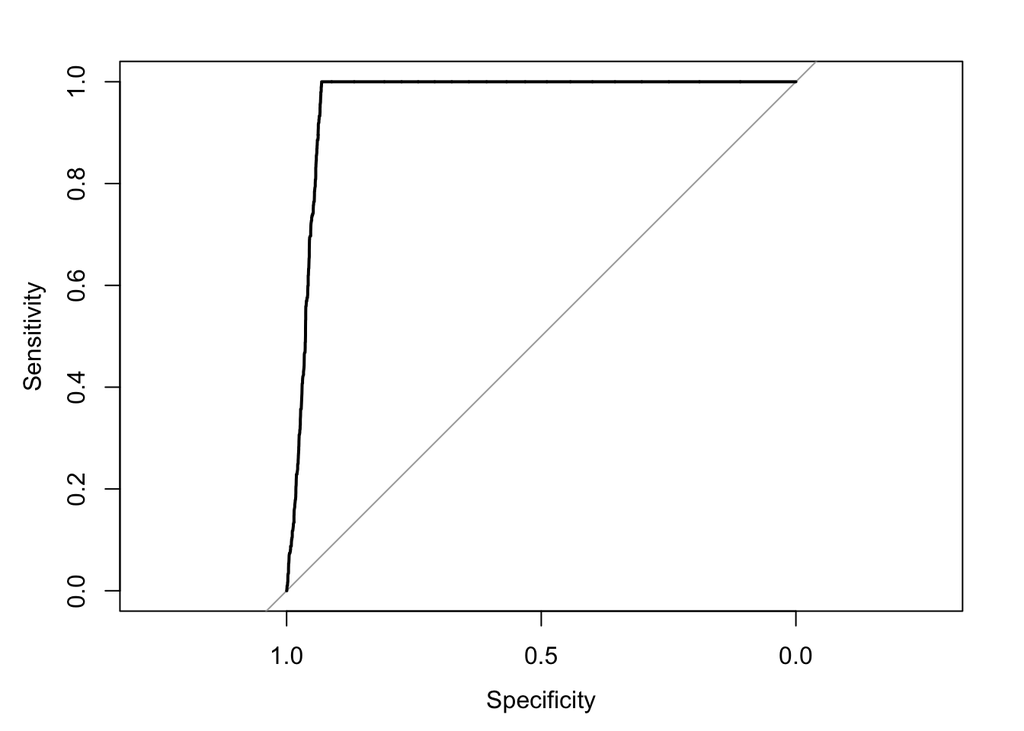

```r
plot.roc(roc_obj)
```

## Additional

Change the way the input is encoded. Instead of hot encoding the trajectories, you can for example hot encode the ICD codes.

```r
## add code here
```